# Projeto: Recomendador de filmes

Como são recomendados os filmes para você? Que tipo de recomendadores são os mais comuns? Porque determinados filmes aparecem como sugestão? Esse é o objetivo desse trabalho, demonstrarei os tipos mais comuns de sistema de recomendação, neste caso, com exemplos de filmes.

[figure not shown]

Quais são os tipos mais comuns de motores de recomendação?

- **Filtros colaborativos:** São baseados em informações e comportamentos de outros usuários parecidos com os seus.
- **Filtros baseados em conteúdo:** São baseados em informações das preferências do perfil do usuário, em itens similares ao já adquiridos anteriormente.
- **Sistemas híbridos:** São utilizados combinando os dois sistemas juntos, colaborativo e baseado em conteudo sendo mais efetivo em alguns casos.

Nesse projeto, após uma análise exploratória, irei aplicar o Filtro baseado em conteúdo, no qual o usuário poderá informar o nome do filme e com base na descrição do filme serão recomendados os mais similares.

Na análise exploratória testaremos as seguintes hipóteses:

- Quanto maior sua despesa, maior é a receita arrecadada pelo filme.
- Quanto maior o tempo de execução do filme, maior é a receita arrecadada.
- Quanto maior o gasto na produção do filmes, maior é sua popularidade.
- Quanto maior a quantidade de atores, mais o filme arrecada.
- Quanto maior mais equipe técnica, mais o filme arrecada.

E responderemos às seguintes perguntas:

- Quais são os top 20 filmes mais caros para ser produzido? Qual o nome do que mais gastou?
- Quais são os top 20 filmes mais lucrativos? Qual o nome do que tem a receita mais alta?
- Qual o filme mais popular?
- Qual produtora foi a mais lucrativa?
- Qual produtora foi a mais gastam?

Serão utilizadas técnicas de **Processamento de Linguagem Natural** e **similaridades por Cosseno**.

O conjunto de dados foi extraído do [kaggle](https://www.kaggle.com/tmdb/tmdb-movie-metadata) The Movie Database (conhecido como TMDb) é uma base de dados grátis e de código aberto sobre Filmes e Séries de TV. Criado por Travis Bell em 2008, a diferença para as outras base de dados, é que TMDb é atualizado constantemente pela comunidade. Era conhecido apenas por ser uma base de dados de filmes, mas em 2013 foi adicionado a parte de Séries de TV.

## Importando as bibliotecas

```python
# Para manipulação e visualização
import pandas as pd
import numpy as np
import matplotlib.pyplot as plt
import seaborn as sns
%matplotlib inline
plt.style.use('ggplot')

# Para pré-processamento dos textos
import nltk
from nltk.corpus import stopwords
from nltk import word_tokenize
import re

# para extração de features
from sklearn.feature_extraction.text import TfidfVectorizer

# para similaridades
from sklearn.metrics.pairwise import cosine_similarity

import json

from tqdm.notebook import tqdm
from time import sleep
```

## Conhecendo o conjunto de dados

Vamos importar dois conjuntos de dados disponíveis, o primeiro conjunto de dados (tmdb_5000_credits.csv) contém as seguintes informações:

- **movie_id:** Um identificador único para cada filme.
- **cast:** O nome dos atores principais e coadjuvantes.
- **crew:** O nome do Diretor, Editor, Compositor, Escritor etc.

O segundo conjunto de dados (tmdb_5000_movies.csv) contém as seguintes informações:

- **budget:** O orçamento em que o filme foi feito.
- **genre:** O gênero do filme, ação, comédia, suspense etc.
- **homepage:** Um link para a página inicial do filme.
- **id:** Este é, de fato, o movie_id como no primeiro conjunto de dados.
- **keywords:** As palavras-chave ou tags relacionadas ao filme.
- **original_language:** O idioma em que o filme foi feito.
- **original_title:** O título do filme antes da tradução ou adaptação.
- **overview:** Uma breve descrição do filme.
- **popularity:** Uma quantidade numérica que especifica a popularidade do filme.
- **production_companies:** A casa de produção do filme.
- **production_countries:** O país em que foi produzido.
- **release_date:** A data em que foi lançado.
- **revenue:** A receita mundial gerada pelo filme.
- **runtime:** O tempo de execução do filme em minutos.
- **status:** "Lançado" ou "Rumor".
- **tagline:** Slogan do filme.
- **title:** Título do filme.
- **vote_average:** classificações médias que o filme recebeu.
- **vote_count:** a contagem dos votos recebidos.

```python
# importando o conjunto de dados
df_credit = pd.read_csv('data/tmdb_5000_credits.csv')
df_movies = pd.read_csv('data/tmdb_5000_movies.csv')

# convertendo a data em modo datetime
df_movies['release_date'] = pd.to_datetime(df_movies.release_date)

# verificando as primeiras linhas
df_credit.head()
```

|  | movie_id | title | cast | crew |
| --- | --- | --- | --- | --- |
| 0 | 19995 | Avatar | [{"cast_id": 242, "character": "Jake Sully", "... | [{"credit_id": "52fe48009251416c750aca23", "de... |
| 1 | 285 | Pirates of the Caribbean: At World's End | [{"cast_id": 4, "character": "Captain Jack Spa... | [{"credit_id": "52fe4232c3a36847f800b579", "de... |
| 2 | 206647 | Spectre | [{"cast_id": 1, "character": "James Bond", "cr... | [{"credit_id": "54805967c3a36829b5002c41", "de... |
| 3 | 49026 | The Dark Knight Rises | [{"cast_id": 2, "character": "Bruce Wayne / Ba... | [{"credit_id": "52fe4781c3a36847f81398c3", "de... |
| 4 | 49529 | John Carter | [{"cast_id": 5, "character": "John Carter", "c... | [{"credit_id": "52fe479ac3a36847f813eaa3", "de... |

```python
# verificando as primeiras linhas
df_movies.head(2)
```

|  | budget | genres | homepage | id | keywords | original_language | original_title | overview | popularity | production_companies | production_countries | release_date | revenue | runtime | spoken_languages | status | tagline | title | vote_average | vote_count |
| --- | --- | --- | --- | --- | --- | --- | --- | --- | --- | --- | --- | --- | --- | --- | --- | --- | --- | --- | --- | --- |
| 0 | 237000000 | [{"id": 28, "name": "Action"}, {"id": 12, "nam... | http://www.avatarmovie.com/ | 19995 | [{"id": 1463, "name": "culture clash"}, {"id":... | en | Avatar | In the 22nd century, a paraplegic Marine is di... | 150.437577 | [{"name": "Ingenious Film Partners", "id": 289... | [{"iso_3166_1": "US", "name": "United States o... | 2009-12-10 | 2787965087 | 162.0 | [{"iso_639_1": "en", "name": "English"}, {"iso... | Released | Enter the World of Pandora. | Avatar | 7.2 | 11800 |
| 1 | 300000000 | [{"id": 12, "name": "Adventure"}, {"id": 14, "... | http://disney.go.com/disneypictures/pirates/ | 285 | [{"id": 270, "name": "ocean"}, {"id": 726, "na... | en | Pirates of the Caribbean: At World's End | Captain Barbossa, long believed to be dead, ha... | 139.082615 | [{"name": "Walt Disney Pictures", "id": 2}, {"... | [{"iso_3166_1": "US", "name": "United States o... | 2007-05-19 | 961000000 | 169.0 | [{"iso_639_1": "en", "name": "English"}] | Released | At the end of the world, the adventure begins. | Pirates of the Caribbean: At World's End | 6.9 | 4500 |

```python
# checando as dimensões
print(df_movies.shape)
print(df_credit.shape)
```

```
(4803, 20)
(4803, 4)
```

Um dos maiores problemas que temos são os dados faltantes, no qual deveremos tratar de alguma forma, com base no nosso objetivo.

```python
# checando se há dados faltantes
df_credit.isnull().sum()
```

```
movie_id    0
title       0
cast        0
crew        0
dtype: int64
```

```python
# checando se há dados faltantes
pd.DataFrame({'faltas_abs':df_movies.isnull().sum(),
              'prop_falta':df_movies.isnull().sum()/df_movies.shape[0]})
```

|  | faltas_abs | prop_falta |
| --- | --- | --- |
| budget | 0 | 0.000000 |
| genres | 0 | 0.000000 |
| homepage | 3091 | 0.643556 |
| id | 0 | 0.000000 |
| keywords | 0 | 0.000000 |
| original_language | 0 | 0.000000 |
| original_title | 0 | 0.000000 |
| overview | 3 | 0.000625 |
| popularity | 0 | 0.000000 |
| production_companies | 0 | 0.000000 |
| production_countries | 0 | 0.000000 |
| release_date | 1 | 0.000208 |
| revenue | 0 | 0.000000 |
| runtime | 2 | 0.000416 |
| spoken_languages | 0 | 0.000000 |
| status | 0 | 0.000000 |
| tagline | 844 | 0.175724 |
| title | 0 | 0.000000 |
| vote_average | 0 | 0.000000 |
| vote_count | 0 | 0.000000 |

O primeiro conjunto de dados não constam dados faltantes, já no segundo já há mais dados. Verificamos que a coluna *homepage* tem aproximadamente 65%, nesse caso não será problema porque não vamos utilizar essa coluna, então poderemos descarta-la.

Agora vamos olhar se os dados foram importados com seus respectivos tipos corretos.

```python
# checando os tipos dos dados
df_credit.dtypes
```

```
movie_id     int64
title       object
cast        object
crew        object
dtype: object
```

```python
# checando os tipos dos dados
df_movies.dtypes
```

```
budget                           int64
genres                          object
homepage                        object
id                               int64
keywords                        object
original_language               object
original_title                  object
overview                        object
popularity                     float64
production_companies            object
production_countries            object
release_date            datetime64[ns]
revenue                          int64
runtime                        float64
spoken_languages                object
status                          object
tagline                         object
title                           object
vote_average                   float64
vote_count                       int64
dtype: object
```

O dados estão corretos, então não precisamos fazer nenhuma transformação.

## Extraindo features

Antes de começar à explorar, vamos fazer algumas extrações para facilitar as análises, como por exemplo, já vimos que a coluna *genres* contém um dicionário em cada célula e isso não nos dá uma forma otimizada de análise.

```python
# removendo a coluna homepage
df_movies.drop(['homepage'], axis=1, inplace=True)
```

Vamos agora criar uma coluna de descrição, a coluna *tagline* possui algumas células em branco, então vamos preencher os dados *null* com *vazios*, e ai juntar com a coluna *overview*. Vamos fazer isso porque a coluna *tagline* tem alguns valores em branco, juntando com outra não vamos perder informação quando remover.

```python
# preenchendo os vazios
df_movies.tagline.fillna('', inplace=True)

# criando uma coluna de descrição
df_movies['description'] = df_movies['tagline'].map(str) + ' ' + df_movies['overview']

# removendo valores nulos
df_movies = df_movies.dropna().reset_index().drop('index', axis=1)

# checando os dados faltantes
df_movies.isnull().sum()
```

```
budget                  0
genres                  0
id                      0
keywords                0
original_language       0
original_title          0
overview                0
popularity              0
production_companies    0
production_countries    0
release_date            0
revenue                 0
runtime                 0
spoken_languages        0
status                  0
tagline                 0
title                   0
vote_average            0
vote_count              0
description             0
dtype: int64
```

Podemos ver que agora não temos mais dados faltantes, vamos checar pra ver quantas linhas perdemos nessa transformação.

```python
# checando o dataframe com as novas dimensões
df_movies.shape
```

```
(4799, 20)
```

Anteriormente tínhamos 4803 linhas e agora temos 4799, não perdemos quase nada.

Vamos querer também analisar por ano e mês de lançamento, então vamos criar mais essas duas colunas.

```python
df_movies['release_year'] = df_movies.release_date.dt.year
df_movies['release_month'] = df_movies.release_date.dt.month
```

Para extrairmos as colunas que possuem dicionários, vamos criar duas funções utilizando funções *json* que facilitam as extrações das informações nesse formato.

```python
# função para extrair os nomes em cada linha de determinada coluna
def extract_names(coluna):

    # colocando o coluna em uma variável
    col_name = f"{coluna}"

    # criando um dataframe vazio
    df_coluna=pd.DataFrame()

    # colocando um valor para iniciar a contagem no loop
    index=1

    # iterando com um loop na coluna passada como argumento
    for i,each in enumerate(df_movies[f'{coluna}']):


        coluna_list=json.loads(each)
        for coluna in coluna_list:
            df_coluna=pd.concat([df_coluna,pd.DataFrame({"coluna":coluna["name"],
                                                         "movie_id": df_movies.id[i],
                                                         "original_title":df_movies.original_title[i],
                                                         "popularity":df_movies.popularity[i],
                                                         "revenue":df_movies.revenue[i],
                                                         "budget":df_movies.budget[i],
                                                         "release_date":df_movies.release_date[i]},index=[index])],axis=0)

            index+=1

    df_coluna.rename(columns={'coluna':col_name}, inplace=True)

    return df_coluna

#=-=-=-=-=-=-=-=-=-=-=-=-=-=-=-=-=-=-=-=-=-=-=-=-=-=-=-=-=-=-=-=-=-=-=-=-=-=-=-=-=-=-=-=-=-=-=-=-=-=-=-=-=-=-=-=-=-=-=-=-=-=#

# função para extrair os nomes dos dicionarios em cada linha de determinada coluna
def json_decode(data,key):
    result = []
    data = json.loads(data) #convert to jsonjsonn from string
    for item in data: #convert to list from json
        result.append(item[key])
    return result
```

Agora vamos criar alguns dataframes somente com as informações pertinentes que queremos analisar, mas se quisermos agregar com informações de outros dataframes criados, podemos juntar através da coluna *ID*.

```python
# aplicandao a primeira função e extraindo as informações principais de cada dicionário
df_credit['character'] = df_credit.cast.apply(json_decode, key='character')
df_credit['name_character'] = df_credit.cast.apply(json_decode, key='name')
df_credit['department_crew'] = df_credit.crew.apply(json_decode, key='department')
df_credit['job_crew'] = df_credit.crew.apply(json_decode, key='job')
df_credit['name_crew'] = df_credit.crew.apply(json_decode, key='name')
```

```python
# checando as duas primeiras linhas
df_credit.head(2)
```

|  | movie_id | title | cast | crew | character | name_character | department_crew | job_crew | name_crew |
| --- | --- | --- | --- | --- | --- | --- | --- | --- | --- |
| 0 | 19995 | Avatar | [{"cast_id": 242, "character": "Jake Sully", "... | [{"credit_id": "52fe48009251416c750aca23", "de... | [Jake Sully, Neytiri, Dr. Grace Augustine, Col... | [Sam Worthington, Zoe Saldana, Sigourney Weave... | [Editing, Art, Sound, Sound, Production, Sound... | [Editor, Production Design, Sound Designer, Su... | [Stephen E. Rivkin, Rick Carter, Christopher B... |
| 1 | 285 | Pirates of the Caribbean: At World's End | [{"cast_id": 4, "character": "Captain Jack Spa... | [{"credit_id": "52fe4232c3a36847f800b579", "de... | [Captain Jack Sparrow, Will Turner, Elizabeth ... | [Johnny Depp, Orlando Bloom, Keira Knightley, ... | [Camera, Directing, Production, Writing, Writi... | [Director of Photography, Director, Producer, ... | [Dariusz Wolski, Gore Verbinski, Jerry Bruckhe... |

```python
# df_genre = extract_names('genres')
df_production_companies = extract_names('production_companies')
df_production_countries = extract_names('production_countries')
```

```python
# df_genre.head()
```

```python
# df_movies['genres'] = df_movies.genres.apply(json_decode, key='name')
df_movies['keywords'] = df_movies.keywords.apply(json_decode, key='name')
df_movies['production_companies'] = df_movies.production_companies.apply(json_decode, key='name')
df_movies['production_countries'] = df_movies.production_countries.apply(json_decode, key='name')
df_movies['spoken_languages'] = df_movies.spoken_languages.apply(json_decode, key='name')
```

```python
df_movies.head(2)
```

|  | budget | genres | id | keywords | original_language | original_title | overview | popularity | production_companies | production_countries | ... | runtime | spoken_languages | status | tagline | title | vote_average | vote_count | description | release_year | release_month |
| --- | --- | --- | --- | --- | --- | --- | --- | --- | --- | --- | --- | --- | --- | --- | --- | --- | --- | --- | --- | --- | --- |
| 0 | 237000000 | [{"id": 28, "name": "Action"}, {"id": 12, "nam... | 19995 | [culture clash, future, space war, space colon... | en | Avatar | In the 22nd century, a paraplegic Marine is di... | 150.437577 | [Ingenious Film Partners, Twentieth Century Fo... | [United States of America, United Kingdom] | ... | 162.0 | [English, Español] | Released | Enter the World of Pandora. | Avatar | 7.2 | 11800 | Enter the World of Pandora. In the 22nd centur... | 2009 | 12 |
| 1 | 300000000 | [{"id": 12, "name": "Adventure"}, {"id": 14, "... | 285 | [ocean, drug abuse, exotic island, east india ... | en | Pirates of the Caribbean: At World's End | Captain Barbossa, long believed to be dead, ha... | 139.082615 | [Walt Disney Pictures, Jerry Bruckheimer Films... | [United States of America] | ... | 169.0 | [English] | Released | At the end of the world, the adventure begins. | Pirates of the Caribbean: At World's End | 6.9 | 4500 | At the end of the world, the adventure begins.... | 2007 | 5 |

2 rows × 22 columns

```python
df_movies_full = pd.merge(df_movies, df_credit[['movie_id', 'character', 'name_character', 'department_crew']], left_on='id', right_on='movie_id').drop('movie_id', axis=1)
```

```python
df_movies_full['cast_amount'] = df_movies_full.name_character.apply(len)
```

```python
df_movies_full['crew_amount'] = df_movies_full.department_crew.apply(len)
```

## Análise Exploratória de Dados

É uma abordagem que tem por objetivo, resumir suas principais características, frequentemente com métodos visuais. Este método pode ser usado simplesmente para conhecer os dados, responder perguntas ou até mesmo validar hipóteses, mostrando de fato como o negócio é, desmestificando alguns achismos ou crenças do time de Negócios.

Vamos começar fazendo uma análise estatística geral do conjunto, primeiro com dados numéricos e em seguida com os dados categóricos.

```python
# checando as principais estatísticas
df_movies_full.describe()
```

|  | budget | id | popularity | revenue | runtime | vote_average | vote_count | release_year | release_month | cast_amount | crew_amount |
| --- | --- | --- | --- | --- | --- | --- | --- | --- | --- | --- | --- |
| count | 4.799000e+03 | 4799.000000 | 4799.000000 | 4.799000e+03 | 4799.000000 | 4799.000000 | 4799.000000 | 4799.000000 | 4799.000000 | 4799.000000 | 4799.000000 |
| mean | 2.906593e+07 | 56899.920192 | 21.509884 | 8.232920e+07 | 106.903105 | 6.094186 | 690.789123 | 2002.461138 | 6.794332 | 22.138987 | 27.000000 |
| std | 4.073251e+07 | 88236.500208 | 31.824074 | 1.629076e+08 | 22.561305 | 1.188340 | 1234.941795 | 12.414480 | 3.423371 | 19.582407 | 31.633445 |
| min | 0.000000e+00 | 5.000000 | 0.000372 | 0.000000e+00 | 0.000000 | 0.000000 | 0.000000 | 1916.000000 | 1.000000 | 0.000000 | 0.000000 |
| 25% | 8.000000e+05 | 9012.500000 | 4.685547 | 0.000000e+00 | 94.000000 | 5.600000 | 54.000000 | 1999.000000 | 4.000000 | 11.000000 | 8.000000 |
| 50% | 1.500000e+07 | 14623.000000 | 12.929525 | 1.918402e+07 | 103.000000 | 6.200000 | 236.000000 | 2005.000000 | 7.000000 | 17.000000 | 16.000000 |
| 75% | 4.000000e+07 | 58461.500000 | 28.350728 | 9.295652e+07 | 118.000000 | 6.800000 | 737.500000 | 2011.000000 | 10.000000 | 25.000000 | 32.000000 |
| max | 3.800000e+08 | 447027.000000 | 875.581305 | 2.787965e+09 | 338.000000 | 10.000000 | 13752.000000 | 2017.000000 | 12.000000 | 224.000000 | 435.000000 |

Podemos ter uma visão geral das principais estatísticas e mais a frente vamos analisar mais especificamente com gráficos.

```python
# checando as principais estatísticas categóricas
df_movies_full.describe(include=['O'])
```

|  | genres | keywords | original_language | original_title | overview | production_companies | production_countries | spoken_languages | status | tagline | title | description | character | name_character | department_crew |
| --- | --- | --- | --- | --- | --- | --- | --- | --- | --- | --- | --- | --- | --- | --- | --- |
| count | 4799 | 4799 | 4799 | 4799 | 4799 | 4799 | 4799 | 4799 | 4799 | 4799 | 4799 | 4799 | 4799 | 4799 | 4799 |
| unique | 1175 | 4220 | 37 | 4797 | 4799 | 3695 | 469 | 530 | 3 | 3945 | 4796 | 4799 | 4746 | 4759 | 4129 |
| top | [{"id": 18, "name": "Drama"}] | [] | en | Batman | Five years after a zombie outbreak, the men an... | [] | [United States of America] | [English] | Released |  | The Host | A power beyond measure requires a protector wi... | [] | [] | [Directing, Writing] |
| freq | 369 | 410 | 4503 | 2 | 1 | 349 | 2977 | 3170 | 4791 | 840 | 2 | 1 | 41 | 41 | 196 |

Agora vamos começar a analisar mais a fundo nosso dataset para validarmos algumas hipóteses e respondendo à outras perguntas.

Vamos começar olhando a distribuição do conjunto de dados numéricos, pra isso vamos criar uma outra variável específica para isso, somente com as variáveis mais relevantes.

Os valores monetários em dólares estão muito extensos, então vamos dividir por um milhão para ficar mais apresentável e facilitar a visualização.

```python
# selecionando somente as colunas numéricas
df_numberic_type = df_movies_full.select_dtypes(np.number).drop(['id','release_year','release_month'], axis=1)

# dividindo em milhão
df_numberic_type["budget (in million $)"] = df_numberic_type.budget/1000000
df_numberic_type["revenue (in million $)"] = df_numberic_type.revenue/1000000

# removendo as colunas originais
df_numberic_type.drop(['budget', 'revenue'], axis=1, inplace=True)
```

Depois das definições acima, vamos agora configurar o nosso plot, vamos criar 8 gráficos de distribuição normal, que são as 8 colunas numéricas que escolhemos.

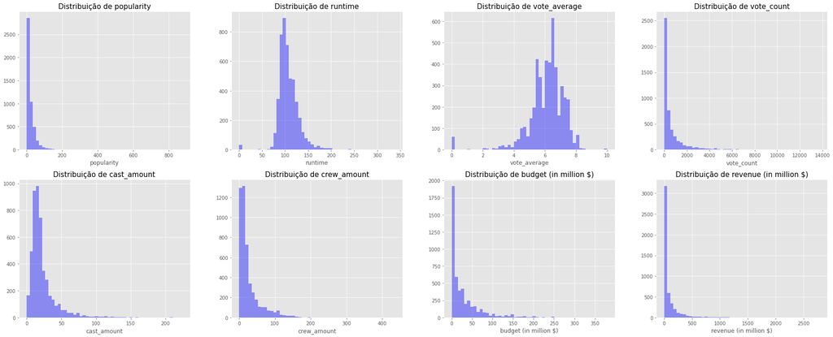

```python
# colocando as colunas em uma lista
colunas = df_numberic_type.columns.tolist()

# definindo a área de plotagem
nrow=2
ncol=4
fig, ax = plt.subplots(nrows=nrow, ncols=ncol, figsize=(25,10))
fig.subplots_adjust(hspace=1, wspace=1)

# plotando gráfico de densidade
idx=0
for col in colunas:
    idx+=1
    plt.subplot(nrow, ncol, idx)
    sns.distplot(df_numberic_type[col], color='blue', kde=False)
    plt.title(f'Distribuição de {col}', fontsize=15)
plt.tight_layout()
```

```python
df_numberic_type.vote_average.mean()
```

```
6.094186288810169
```

Então, vamos começar a responder as hipóteses.

### Quanto maior sua despesa, maior é a receita arrecadada pelo filme.

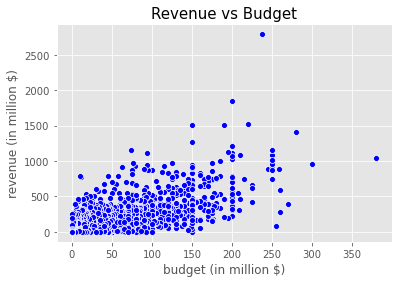

```python
# verificando a relação entre despesas e receita
sns.scatterplot(x='budget (in million $)', y='revenue (in million $)', data=df_numberic_type, color='blue')
plt.title('Revenue vs Budget', fontsize=15);
```

Podemos **validar essa hipótese**, pois podemos ver o investimento na produção influencia positivamente a receita, para os filmes.

### Quanto maior o tempo de execução do filme, maior é a receita arrecadada.

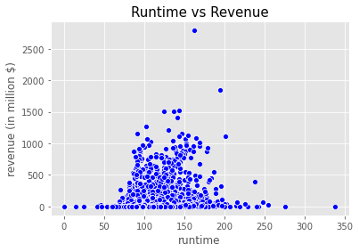

```python
# verificando a relação entre tempo de execução e receita
sns.scatterplot(x='runtime', y='revenue (in million $)', data=df_numberic_type, color='blue')
plt.title('Runtime vs Revenue', fontsize=15);
```

### Quanto maior o gasto na produção do filmes, maior é sua popularidade.

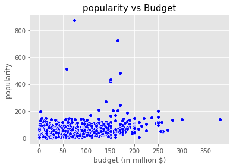

```python
# verificando a relação entre despesas e popularidade
sns.scatterplot(x='budget (in million $)', y='popularity', data=df_numberic_type, color='blue')
plt.title('popularity vs Budget', fontsize=15);
```

Podemos notar uma correlação moderada, com alguns outliers, mas não necessariamente que tenha uma despesa maior significa que a popularidade será maior.

### Quanto maior a quantidade de atores, mais o filme arrecada.

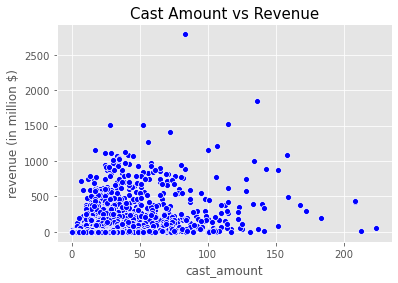

```python
# verificando a relação entre elenco e receita
sns.scatterplot(x='cast_amount', y='revenue (in million $)', data=df_numberic_type, color='blue')
plt.title('Cast Amount vs Revenue', fontsize=15);
```

Também podemos notar uma correlação fraca entre essas duas variáveis.

### Quanto maior mais equipe técnica, mais o filme arrecada.

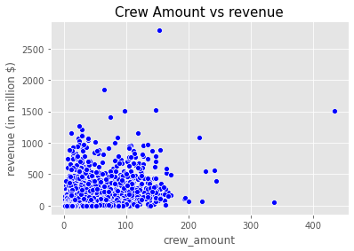

```python
# verificando a relação entre equipe técnica e receita
sns.scatterplot(x='crew_amount', y='revenue (in million $)', data=df_numberic_type, color='blue')
plt.title('Crew Amount vs revenue', fontsize=15);
```

Podemos notar uma correlação moderada, quanto mais pessoas na equipe técnica, maior o receita. Pode ser que a influência se dê em função de ter mais pessoa a produção ficar melhor.

Analisamos as principais variáveis especificamente, mas podemos verificar as correlações entre elas com um heatmap.

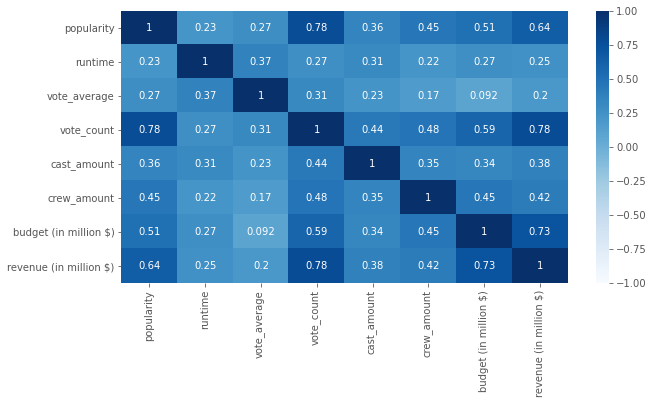

```python
# verificando a relação entre todas as variáveis
plt.figure(figsize=(10,5))
sns.heatmap(df_numberic_type.corr(), vmin=-1, vmax=1, annot=True, cmap='Blues')
```

A correlação vai de -1 à 1, sendo 0 que significa sem correlação nenhuma. Podemos notar as variáveis mais correlacionadas entre si:

- Contagem de votos com popularidade (0.78);
- Contagem de votos com receita (0.78);
- Despesas com receita (0.73), analisamos visualmente.

Com essas informações o time, poderá analisar e ir mais a fundo no que mais tem a ver para melhorar o negócio.

Após checarmos as hipóteses, podem ser levantados alguns questionamentos e vamos responder alguns abaixo.

### Quais são os top 20 filmes mais caros para ser produzido? Qual o nome do que mais gastou?

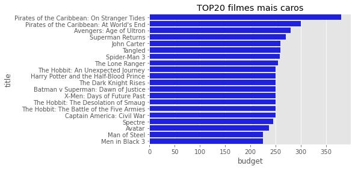

```python
# agrupando os filmes por título e extraindo as informações de despesas
top20_film_budget = pd.DataFrame(df_movies.groupby('title')['budget'].mean().sort_values(ascending=False)/1000000).reset_index().head(20)

# plotando o gráfico
# plt.figure(figsize=(10,5))
sns.barplot(x=top20_film_budget.budget, y=top20_film_budget.title, color='blue')
plt.title('TOP20 filmes mais caros');
```

O filme **Piratas do Caribe** foi o mais caro a ser produzido.

### Quais são os top 20 filmes mais lucrativos? Qual o nome do que tem a receita mais alta?

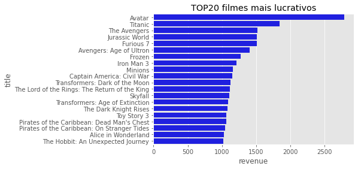

```python
# agrupando os filmes por título e extraindo as informações de receita
top20_film_revenue = pd.DataFrame(df_movies.groupby('title')['revenue'].mean().sort_values(ascending=False)/1000000).reset_index().head(20)

# plotando o gráfico
# plt.figure(figsize=(10,5))
sns.barplot(x=top20_film_revenue.revenue, y=top20_film_revenue.title, color='blue')
plt.title('TOP20 filmes mais lucrativos');
```

O filme **Avatar** foi o mais lucrativo.

### Qual o filme mais popular?

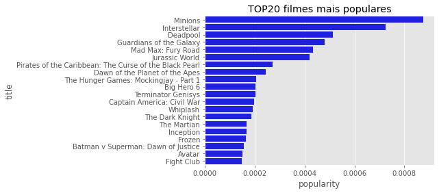

```python
# agrupando os filmes por título e extraindo as informações de popularidade
top20_film_pop = pd.DataFrame(df_movies.groupby('title')['popularity'].mean().sort_values(ascending=False)/1000000).reset_index().head(20)

# plotando o gráfico
# plt.figure(figsize=(10,5))
sns.barplot(x=top20_film_pop.popularity, y=top20_film_pop.title, color='blue')
plt.title('TOP20 filmes mais populares');
```

**Minions** é o filme mais popular.

### Qual produtora foi a mais lucrativa?

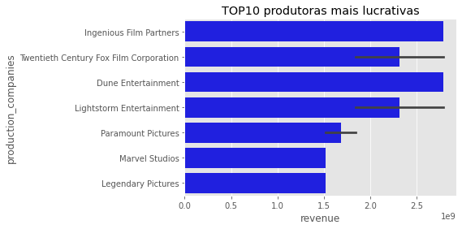

```python
# classificando por ordem as produtoras mais lucrativas
df_production_companies_r = df_production_companies.sort_values(by='revenue', ascending=False).head(10)

# plotando o gráfico
# plt.figure(figsize=(10,5))
sns.barplot(y=df_production_companies_r.production_companies, x=df_production_companies_r.revenue, color='blue')
plt.title('TOP10 produtoras mais lucrativas');
```

### Qual produtora foi a mais gastam?

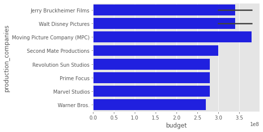

```python
# classificando por ordem as produtoras que mais gastam
df_production_companies_b = df_production_companies.sort_values(by='budget', ascending=False).head(10)

# plotando o gráfico
# plt.figure(figsize=(10,5))
sns.barplot(y=df_production_companies_b.production_companies, x=df_production_companies_b.budget, color='blue')
```

Após toda essa análise exploratória, partiremos a criar o nosso modelo.

Esse modelo é baseado em conteúdo, utilizando técnicas de NLP e aplicando a função **coseno** para retornar os filmes mais similares, abaixo descrevo brevemente sobre essa função.

Vamos iniciar selecionando as colunas principais para o nosso modelo.

```python
# mantendo as principais colunas
df1 = df_movies_full[['title', 'tagline', 'overview', 'popularity', 'description']]
```

## Construindo o Sistema Recomendador de filmes

Os seguintes passos serão seguidos:

1. Pré-processamento do texto
2. Engenharia de features
3. Computar as similaridades dos documentos
4. Encontrar os tops filmes similares
5. Construir a função para recomendação de filmes

### 1. Pré-processamento do texto

É a tarefa de deixar o texto previsível e analizável, a cada análise que envolva NLP é necessário avaliar as técnicas que serão empregadas, pois não há uma única forma para utilizar em tudo. Por exemplo, se quero analisar as palavras mais comuns que aparecem em determinado documento, se remover stopwords pode ser que eu estarei removendo outras informações importantes assim como utilizar lemmatization ou stemming, há casos em que não são aplicáveis.

Também conhecido como normalização de textos, na célula abaixo trataremos de criar uma função para isso. Com um conhecimento prévio, ou pessoas que conheçam do negócio para te auxiliar, podemos desenvolver e ir testando até chegar no nosso objetivo.

Como o texto está em inglês, removeremos stopwords desse idioma, assim como caracteres especiais e passaremos todas as palavras para minúsculas e também removeremos espaços que estão a mais.

Observe que neste caso não vamos utilizar lemmatization e stemming.

```python
# objeto para stopwords
stop_words = stopwords.words('english')

# função para normalização do texto
def normalize_doc(doc):
    # removendo caracteres especiais
    doc = re.sub(r'[^a-zA-Z0-9\s]', '', doc, re.I|re.A)

    # convertendo em minusculas
    doc = doc.lower()

    # removendo espaços indesejados no final
    doc = doc.strip()

    # tokenizando os documentos
    tokens = word_tokenize(doc)

    # filtrando as stopwords
    filtered_tokens = [token for token in tokens if token not in stop_words]

    # juntando o tokens com o texto limpo
    doc = ' '.join(filtered_tokens)

    # resultado final
    return doc
```

Antes de aplicar a função vamos criar uma instância vetorizando a função para aplicar nos documentos, com o método vectorize do numpy, mas o que essa função faz? Ela pega objetos ou matrizes como entrada e retorna uma única matriz numpy, no nosso caso será retornado uma matriz com os textos normalizados.

```python
# instanciando um objeto para vetorizar a função criada
normalize_corpus = np.vectorize(normalize_doc)
```

Agora vamos executar a função e ver dar uma olhada em sua dimensão.

```python
# executando a função
norm_corpus = normalize_corpus(list(df1['description']))

#  olhando o tamanho do corpus
norm_corpus.shape
```

```
(4799,)
```

Eis o resultado da vetorização, ele converteu um objeto de uma coluna do dataframe em um array numpy com os documentos.

### 2. Engenharia de features com TF-IDF

O valor TF-IDF, do termo em inglês *Term Frequency - Inverse Document Frequency*, que significa *Frequencia do Termo - inverso da frequencia nos documentos*, serve para indicar a importância de uma palavra de um documento em relação a uma coleção de documentos ou em um *corpus linguistico*.

Esse valor para uma palavra aumenta proporcionalmente à medida que aumenta o número de ocorrências em um documento, no entanto, esse valor é equilibrado pela frequencia da palavra no corpus, com isso auxilia a distinguir o fato da ocorrência de algumas palavras serem geralmente mais comuns que outras.

Vamos iniciar instanciando um objeto com *TfidfVectorizer*, com alguns parâmetros, que melhor atende nosso objetivo. O resultado será uma matriz com os valores.

```python
# instanciando o tf-idf
tf = TfidfVectorizer(ngram_range=(1, 2), min_df=2)

# treinando e transformando o corpus
tfidf_matrix = tf.fit_transform(norm_corpus)

# checando as dimensões da matriz
tfidf_matrix.shape
```

```
(4799, 20659)
```

A matriz sparsa resultante possui 20659 colunas e a quantidade de linhas se mantém.

### 3. Computando as similaridades

Há varias formas de se calcular as similaridades utilizando distâncias como *Euclidean*, *Manhattan*, *Jaccard* ou *cosine*... No nosso caso vamos empregar o cálculo de similaridade por coseno, pois essa métrica mede a similaridade entre dois vetores, utilizando o cosseno do ângulo entre eles, em tese verifica se estão apontando aproximadamente para a mesma direção, sendo o score de 0 à 1, quando 1 estão de fato indo para a mesma direção. O cálculo se dá pela equação abaixo.

$ similarity = cos(\theta) = {\frac{A.B}{||A|| . ||B||}} = {\frac{\sum \limits _{i=1} ^{n} . A_{i}.B_{i}}{\sqrt{\sum \limits _{i=1} ^{n}.A_{i}^2} . \sqrt{\sum \limits _{i=1} ^{n}.B_{i}^2}}} $

Vamos utilizar a função *cosine_similarity* do *scikit-learn*, passando como argumento a matriz tf-idf que calculamos anteriormente.

```python
# calculando as similaridades na matriz
doc_sim = cosine_similarity(tfidf_matrix)

# colocando em um dataframe
doc_sim_df = pd.DataFrame(doc_sim)

# verificando as primeiras linhas
doc_sim_df.head()
```

|  | 0 | 1 | 2 | 3 | 4 | 5 | 6 | 7 | 8 | 9 | ... | 4789 | 4790 | 4791 | 4792 | 4793 | 4794 | 4795 | 4796 | 4797 | 4798 |
| --- | --- | --- | --- | --- | --- | --- | --- | --- | --- | --- | --- | --- | --- | --- | --- | --- | --- | --- | --- | --- | --- |
| 0 | 1.000000 | 0.010701 | 0.00000 | 0.019029 | 0.028685 | 0.0249 | 0.000000 | 0.026516 | 0.000000 | 0.007419 | ... | 0.009701 | 0.0 | 0.023336 | 0.033549 | 0.000000 | 0.000000 | 0.0 | 0.006889 | 0.000000 | 0.000000 |
| 1 | 0.010701 | 1.000000 | 0.01189 | 0.000000 | 0.041622 | 0.0000 | 0.014562 | 0.027121 | 0.034687 | 0.007614 | ... | 0.009955 | 0.0 | 0.004817 | 0.000000 | 0.000000 | 0.012592 | 0.0 | 0.022382 | 0.013724 | 0.000000 |
| 2 | 0.000000 | 0.011890 | 1.00000 | 0.000000 | 0.000000 | 0.0000 | 0.000000 | 0.022242 | 0.015853 | 0.004891 | ... | 0.042615 | 0.0 | 0.000000 | 0.000000 | 0.016519 | 0.000000 | 0.0 | 0.011677 | 0.000000 | 0.003999 |
| 3 | 0.019029 | 0.000000 | 0.00000 | 1.000000 | 0.008792 | 0.0000 | 0.015973 | 0.023171 | 0.027451 | 0.073607 | ... | 0.000000 | 0.0 | 0.009666 | 0.000000 | 0.000000 | 0.000000 | 0.0 | 0.028343 | 0.021783 | 0.027732 |
| 4 | 0.028685 | 0.041622 | 0.00000 | 0.008792 | 1.000000 | 0.0000 | 0.022909 | 0.028676 | 0.000000 | 0.023536 | ... | 0.014799 | 0.0 | 0.000000 | 0.000000 | 0.000000 | 0.010760 | 0.0 | 0.010509 | 0.000000 | 0.000000 |

5 rows × 4799 columns

Foram calculados a similaridades em cada linha contra cada linha do dataframe, semelhante a uma matriz de correlação, as linhas 0 e 0 por exemplo tem score 1 porque é ela própria e a similaridade tem o valor máximo.

```python
# convertendo a coluna title em uma lista
movies_list = df1.title.values

# olhando a dimensão
movies_list.shape
```

```
(4799,)
```

### 4 Encontrando os mais similares com base em uma amostra

```python
# ordenando por popularidade (do mais popular)
pop_movies = df1.sort_values('popularity', ascending=False)
pop_movies.head()
```

|  | title | tagline | overview | popularity | description |
| --- | --- | --- | --- | --- | --- |
| 546 | Minions | Before Gru, they had a history of bad bosses | Minions Stuart, Kevin and Bob are recruited by... | 875.581305 | Before Gru, they had a history of bad bosses M... |
| 95 | Interstellar | Mankind was born on Earth. It was never meant ... | Interstellar chronicles the adventures of a gr... | 724.247784 | Mankind was born on Earth. It was never meant ... |
| 788 | Deadpool | Witness the beginning of a happy ending | Deadpool tells the origin story of former Spec... | 514.569956 | Witness the beginning of a happy ending Deadpo... |
| 94 | Guardians of the Galaxy | All heroes start somewhere. | Light years from Earth, 26 years after being a... | 481.098624 | All heroes start somewhere. Light years from E... |
| 127 | Mad Max: Fury Road | What a Lovely Day. | An apocalyptic story set in the furthest reach... | 434.278564 | What a Lovely Day. An apocalyptic story set in... |

```python
# localizando o ID, no nosso caso, do mais popular
movie_idx = np.where(movies_list == 'Minions')[0][0]
movie_idx
```

```
546
```

```python
# encontrando os filmes similares
movie_similarities = doc_sim_df.iloc[movie_idx].values
movie_similarities
```

```
array([0.01045346, 0.01072743, 0.        , ..., 0.00690641, 0.        ,
       0.        ])
```

```python
# selecionando os 5 mais populares IDs
similar_movie_idxs = np.argsort(-movie_similarities)[1:6]
similar_movie_idxs
```

```
array([506, 614, 241, 813, 154], dtype=int64)
```

```python
# descrevendo os 5 filmes mais populares
similar_movies = movies_list[similar_movie_idxs]
similar_movies
```

```
array(['Despicable Me 2', 'Despicable Me',
       'Teenage Mutant Ninja Turtles: Out of the Shadows', 'Superman',
       'Rise of the Guardians'], dtype=object)
```

### 5. Construindo um recomendador de filmes

```python
# criando a função para o recomendador de filmes
def movie_recommender(movie_title, movies=movies_list, doc_sims=doc_sim_df):
    # encontrando o ID do filme
    movie_idx = np.where(movies == movie_title)[0][0]

    # descrevendo os filmes mais similares
    movie_similarities = doc_sims.iloc[movie_idx].values

    # encontrando os IDs dos 5 primeiros filmes mais similares
    similar_movie_idxs = np.argsort(-movie_similarities)[1:6]

    # descrevendo os 5 filmes mais similares
    similar_movies = movies[similar_movie_idxs]

    # retornando com o resultado
    return similar_movies
```

```python
# criando lista dos 10 mais populares do nosso conjunto
popular_movies = pop_movies.title.tolist()[1:11]
```

```python
# recomendando os filmes para essa lista
for movie in popular_movies:
    print('Movie:', movie)
    print('Top 5 filmes recomendados:', movie_recommender(movie_title=movie))
    print('\n**************************************************************************************')
```

```
Movie: Interstellar
Top 5 filmes recomendados: ['Gattaca' 'Space Pirate Captain Harlock' 'Space Cowboys'
 'Starship Troopers' 'Final Destination 2']

Movie: Deadpool
Top 5 filmes recomendados: ['Silent Trigger' 'Underworld: Evolution' 'Bronson' 'Shaft' 'Don Jon']

Movie: Guardians of the Galaxy
Top 5 filmes recomendados: ['Chasing Mavericks' 'E.T. the Extra-Terrestrial' 'American Sniper'
 'The Amazing Spider-Man 2' 'Hoop Dreams']

Movie: Mad Max: Fury Road
Top 5 filmes recomendados: ['The 6th Day' 'Star Trek Beyond' 'Kites' 'The Orphanage'
 'The Water Diviner']

Movie: Jurassic World
Top 5 filmes recomendados: ['Jurassic Park' 'The Lost World: Jurassic Park' 'The Nut Job'
 "National Lampoon's Vacation" 'Vacation']

Movie: Pirates of the Caribbean: The Curse of the Black Pearl
Top 5 filmes recomendados: ["Pirates of the Caribbean: Dead Man's Chest" 'The Pirate'
 'Pirates of the Caribbean: On Stranger Tides'
 'The Pirates! In an Adventure with Scientists!' 'Joyful Noise']

Movie: Dawn of the Planet of the Apes
Top 5 filmes recomendados: ['Battle for the Planet of the Apes' 'Groove' 'The Other End of the Line'
 'Chicago Overcoat' 'Definitely, Maybe']

Movie: The Hunger Games: Mockingjay - Part 1
Top 5 filmes recomendados: ['The Hunger Games: Catching Fire' 'The Hunger Games: Mockingjay - Part 2'
 'John Carter' 'For Greater Glory - The True Story of Cristiada'
 'The Proposition']

Movie: Big Hero 6
Top 5 filmes recomendados: ['Wreck-It Ralph' 'A Home at the End of the World' 'Phat Girlz' 'Splice'
 'U.F.O.']

Movie: Terminator Genisys
Top 5 filmes recomendados: ['Terminator 2: Judgment Day' 'Terminator Salvation'
 'Terminator 3: Rise of the Machines' 'Mad Max'
 'X-Men: Days of Future Past']
```

## Conclusão

Essa foi uma demonstração de um simples *engine* para recomendar filmes com base na descrição do filme, claro que existem outros, porém a adaptação também é simples para testar outros modelos, assim também como inclusão de outras *features* que refinariam ainda mais o resultado da busca.  
Além disso esse modelo pode servir para outros temas como por exemplo, um conjunto de dados de problemas em uma linha de produção, facilmente pode ser adaptado para encontrar, em uma base de dados, problemas similares com base no conteúdo descrito.

## Referências

https://github.com/Apress/text-analytics-w-python-2e/blob/master/Ch07%20-%20Text%20Similarity%20and%20Clustering/Ch07b%20-%20Movie%20Recommender%20with%20Document%20Similarity.ipynb

https://rstudio-pubs-static.s3.amazonaws.com/369891_b123051c3cb64da5a6d22a8d0b6e0d84.html

https://www.kaggle.com/eaybek/examination-of-genres-through-year-and-month

https://www.kaggle.com/tmdb/tmdb-movie-metadata

https://movile.blog/sistemas-de-recomendacao-com-filtros-colaborativos/

https://realpython.com/build-recommendation-engine-collaborative-filtering/